# ChlorLine

Gabriela Feres Chiappetta Lisa Kamtchatnova Douglas Campbell

# 1.0 Introduction

Mudflats are a bio-diverse, highly productive coastal and estuarine habitat home to microphytobenthic diatoms, which carry out keystone functions and are responsible for 50% of estuarine primary productivity (Herlory et al., 2004). Motile microphytobenthic diatoms, predominantly pennate diatoms, engage in vertical migrations to the surface of mudflats to carry out keystone functions during low tide and migrate back down during high tide (Conslavey et al., 2011). These migrations are asymmetrical, with diatoms migrating much quicker upward than downward to maximize light exposure for photosynthesis. Studies in estuaries around the world have shed light on their migratory patterns, however, no such studies have been done in the Bay of Fundy,in New Brunswick. We aim to analyze the effects of temperature on the amplitude of vertical migration of microphytobenthic diatoms from in The Bay of Fundy by looking at chlorophyll output and doing manual cell counts.

## 1.2 Hypothesis

Temperature variation will have an effect on the amplitude of vertical migration.

# 2.0 Methods

Mudflat sediment from Peg’s Cove from the Bay of Fundy was collected and distributed among three lasagna pans, excess water was eliminated via a baster, and the sediment was left moist. Lens papers were cut into 2 x 2 cm squares and placed in pairs, one paper on top of the other, onto the sediment.

To analyze how much chlorophyll was found on each paper, each paper was placed in a test tube and re-submerged with 2-4mL of development solvent (Acetone and DMSO). Dilution was performed on certain samples to keep chlorophyll readings within range of the Chlorophyll Fluorometer results were recorded and graphed.

A test run was performed at 23ºC two weeks before the final execution of our experiment. We included the results of the test run in our analysis.

## 2.2 Install packages

```r
#install.packages("tidyverse")
#install.packages("kableExtra")
```

## 2.3 Load Packages

```r
library(tidyverse)
library(kableExtra)
library(broom)
```

## 2.4 Read file

```r
vert_migration <- readRDS( file = file.path("..","Data","CleanData","vert_migration.rds"))
```

# 3.0 Results

## 3.1 Figure 1. Chlorophyll concentration at hight tide in the Bay of Fundy at 15°C, 20°C, and 23°C

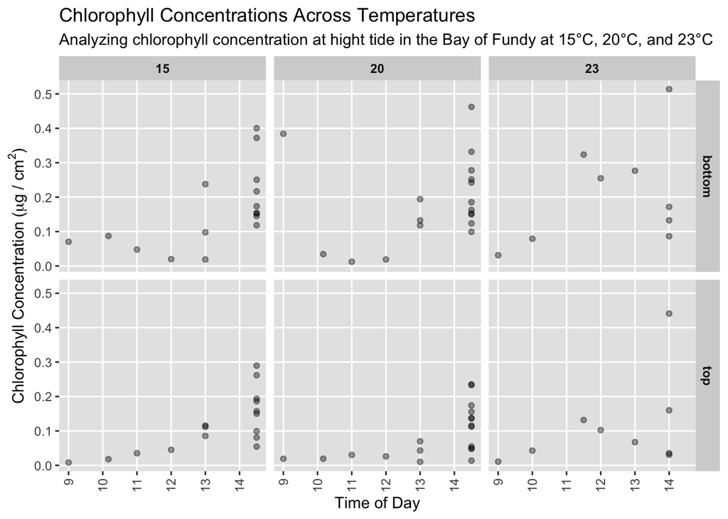

```r
vert_migration |>
  ggplot() +
  geom_point(aes(x = ToD, y = Chl_ugcm2), alpha = 0.4) +
  facet_grid(rows = vars(Top_Bottom), cols = vars(Temp_C)) +
  labs(
    x = "Time of Day",
    y = expression("Chlorophyll Concentration ("*mu*"g / cm"^2*")"),
    title = "Chlorophyll Concentrations Across Temperatures",
    subtitle = "Analyzing chlorophyll concentration at hight tide in the Bay of Fundy at 15°C, 20°C, and 23°C",

  ) +
  theme(
    axis.text.x = element_text(angle = 90, vjust = 0.5, hjust = 1), # Rotate x-axis labels for readability
    panel.background = element_rect(fill = "gray90"),
    panel.grid.major = element_line(color = "white"),
    panel.grid.minor = element_blank(),
    strip.background = element_rect(fill = "lightgray"),
    strip.text = element_text(face = "bold")
  )
```

The bottom layer of paper has a higher chlorophyll concentration than top layer at all temperature levels.

There is more chlorophyll concentration detected as time approaches to 1400hr (end of day) for the top layer at 15ºC and 20ºC, suggesting migration to the top is increasing with time.

Top to bottom ratio of chlorophyll concentration were analysed next to visualize our results without the scatter in these graphs.

## 3.2 Creating a TopBottomRatio variable

The vert_migration contains variable Top_Bottom, that describes if the sample was measure from the top or the bottom layer of lens paper. To simplify ratio calculation we used ‘pivot_wider’ in the data to separate Top_Bottom into two separate variables, Top & Bottom; that lowers the number of rows and increases the number of columns.This new variable eliminates the scatter seen in the plot above.

```r
vert_migration_wide <- vert_migration |>
  select(-c(Tissue_Area_cm2, VolSol_mL, Fluorescence_Reading, `...19`,  Chl_ugL)) |>
  pivot_wider(id_cols = c(YYYYMMDDHHMM, Replicate, Temp_C, Light, Trial, DateTime, Date, ToD, E_time_h), names_from = Top_Bottom, values_from = Chl_ugcm2, values_fn = mean) |>
  mutate(TopBottomRatio = top/bottom)
```

## 3.3 Figure 2. Ratio of Top Chl_ugcm2 to Bottom Chl_ugcm2, Chlorophyll concentration top to bottom ratios at temperatures 15°C, 20°C, and 23°C

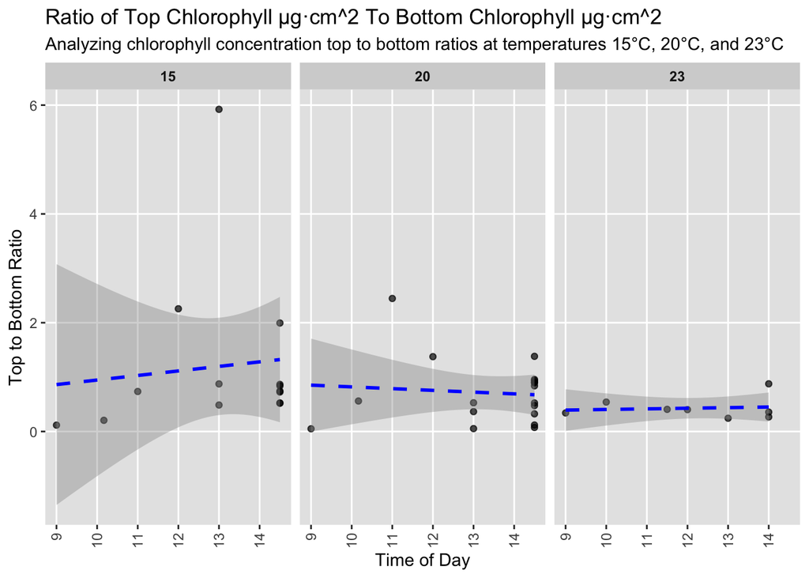

```r
vert_migration_wide |>
  ggplot() +
  geom_point(aes(x = ToD, y = TopBottomRatio), alpha = 0.7) +
  geom_smooth(aes(x = ToD, y = TopBottomRatio), method = "lm", se = TRUE, color = "blue", linetype = "dashed") +
  facet_grid(cols = vars(Temp_C)) +
  labs(
    x = "Time of Day",
    y = "Top to Bottom Ratio",
    title = "Ratio of Top Chlorophyll µg·cm^2 To Bottom Chlorophyll µg·cm^2",subtitle = "Analyzing chlorophyll concentration top to bottom ratios at temperatures 15°C, 20°C, and 23°C",
  ) +
  theme(
    axis.text.x = element_text(angle = 90, vjust = 0.5, hjust = 1),
    panel.background = element_rect(fill = "gray90"),
    panel.grid.major = element_line(color = "white"),
    panel.grid.minor = element_blank(),
    strip.background = element_rect(fill = "lightgray"),
    strip.text = element_text(face = "bold")
  )
```

Figure 2 shows the ratio of chlorophyll concentration found on the top layer of lens paper to bottom layer of lens paper. Light level was high for all temperature settings.

Three statistical test were performed, nested regressions, linear regression, and ANOVA, and a statistical trend between vertical migration and temperature was not found. The confidence interval is too wide to attribute a significant trend to variation in temperature.

### 3.3.1 Nested Regression

```r
vert_nest <- vert_migration_wide |>
  nest(.by = Temp_C) |>
  mutate(LinearFit = purrr::map(data, ~lm(TopBottomRatio ~ ToD,
                                            data = .x)),
         LinearTidy = purrr::map(LinearFit, tidy),
         LinearParam = purrr::map(LinearFit, glance),
         LinearPredict = purrr::map(LinearFit, augment)
         )


vert_nest |>
unnest(cols = c(LinearTidy)) |>
 select(-c(data, LinearFit, LinearParam, LinearPredict)) |>
  select(-c(statistic)) |>
  pivot_wider(id_cols = c(Temp_C), names_from = term, values_from = c(estimate, std.error, p.value)) |>
  kable()
```

| Temp_C | estimate_(Intercept) | estimate_ToD | std.error_(Intercept) | std.error_ToD | p.value_(Intercept) | p.value_ToD |
| --- | --- | --- | --- | --- | --- | --- |
| 23 | 0.2922510 | 0.0112671 | 0.5261415 | 0.0427064 | 0.5986633 | 0.8007410 |
| 15 | 0.1106222 | 0.0835540 | 3.0247942 | 0.2296813 | 0.9714278 | 0.7223491 |
| 20 | 1.1413446 | -0.0321161 | 1.1604600 | 0.0861096 | 0.3399875 | 0.7140675 |

We completed a nested regression for each temperature setting to determine if there is any significant slope/trend in our data. And, from the results of the nested regression, there is not a significant trend in any of the temperature settings.

### 3.3.2 Linear regression

```r
summary(lm(TopBottomRatio ~ ToD * Temp_C,
           data = vert_migration_wide))
```

```
##
## Call:
## lm(formula = TopBottomRatio ~ ToD * Temp_C, data = vert_migration_wide)
##
## Residuals:
##     Min      1Q  Median      3Q     Max
## -0.8116 -0.5623 -0.1830  0.1852  4.7232
##
## Coefficients:
##             Estimate Std. Error t value Pr(>|t|)
## (Intercept) -0.64239    6.96049  -0.092    0.927
## ToD          0.25569    0.53750   0.476    0.637
## Temp_C       0.06408    0.36052   0.178    0.860
## ToD:Temp_C  -0.01253    0.02798  -0.448    0.657
##
## Residual standard error: 0.9836 on 36 degrees of freedom
##   (5 observations deleted due to missingness)
## Multiple R-squared:  0.09589,    Adjusted R-squared:  0.02055
## F-statistic: 1.273 on 3 and 36 DF,  p-value: 0.2984
```

### 3.3.3 ANOVA

```r
summary(aov(TopBottomRatio ~ ToD * Temp_C,
           data = vert_migration_wide))
```

```
##             Df Sum Sq Mean Sq F value Pr(>F)
## ToD          1   0.15   0.153   0.158 0.6937
## Temp_C       1   3.35   3.347   3.460 0.0711 .
## ToD:Temp_C   1   0.19   0.194   0.201 0.6570
## Residuals   36  34.83   0.968
## ---
## Signif. codes:  0 '***' 0.001 '**' 0.01 '*' 0.05 '.' 0.1 ' ' 1
## 5 observations deleted due to missingness
```

Both the linear model and the ANOVA suggest that neither ToD nor the interaction between ToD and Temperature significantly affect the TopBottomRatio variable. However, there is a borderline significance for temperature in the ANOVA test, at a p-value of 0.0711, hinting at a possible minor effect of temperature in the TopBottomRatio variable.

The R-squared values in the linear model also indicate that the predictors explain very little of the variability in the TopBottomRatio variable.

# 4.0 Conclusion

In summary, while out data exhibited observable trends these trends were not statistically significant when performing a simple linear regression. The data points were variable and confidence interval too wide to detect a significant trend. Notably, an ANOVA indicated a borderline effect of temperature with a p-value of 0.0711, however, the remaining tests did not support this finding.

If we were to perform this experiment again, triplicate readings for each time interval would be helpful to generate more data points and account for homogeneity in the mudflat.

# 5.0 References

Conslavey, M., Paterson, D. M., & Underwood, G. J. C. (2011). The Ups and Downs of Life in a Benthic Biofilm: Migration of Benthic Diatoms. Diatom Research, 19:2(181–202). https://doi.org/10.1080/0269249X.2004.9705870  
Daggers, T. D., Kromkamp, J. C., Herman, P. M. J., & van der Wal, D. (2018). A model to assess microphytobenthic primary production in tidal systems using satellite remote sensing. Remote Sensing of Environment, 211, 129–145. https://doi.org/10.1016/j.rse.2018.03.037  
Haro, S., Bohórquez, J., Lara, M., Garcia-Robledo, E., González, C. J., Crespo, J. M., Papaspyrou, S., & Corzo, A. (2019). Diel patterns of microphytobenthic primary production in intertidal sediments: The role of photoperiod on the vertical migration circadian rhythm. Scientific Reports, 9(1), 13376. https://doi.org/10.1038/s41598-019-49971-8  
Herlory, O., Guarini, J.-M., Richard, P., & Blanchard, G. F. (2004). Microstructure of microphytobenthic biofilm and its spatio-temporal dynamics in an intertidal mudflat (Aiguillon Nay, France). Marine Ecology Progress Series, 282(33–44). https://doi.org/10.3354/meps282033  
Corp, P. (n.d.). Attractions: Historical. The Weather Network. Retrieved September 13, 2024, from https://www.theweathernetwork.com/ca/forecasts/attractions/historical/nova-scotia/bay-of-fundy-tourism